# ISLET Alzheimer_mice

Ziyi Ou

2024-07-17

```r
library(SummarizedExperiment)
library(SingleCellExperiment)
library(GEOquery)
library(ISLET)
library(Seurat)
library(MuSiC)
library(dplyr)
library(ggplot2)
library(tidyr)
library(fgsea)
library(Matrix)
library(pheatmap)
library(stringr)
library(gridExtra)
library(reshape2)
library(biomaRt)
```

# 1. Overview of data

## 1.1 Experiment Design

To examine molecular changes throughout disease progression, brain tissue from male and female, 3xTg-AD and B6129 control mice, between the ages of 6- and 24-months-old were collected.

- 3xTg-AD Mice: These mice carry three mutations related to Alzheimer’s disease (APPSwe, PS1M146V, TauP301L) and are used for studying Alzheimer’s disease.
- B6129 Control Mice: These are the offspring of hybrid mice from the B6 and 129 strains, used as a control group to eliminate the effects of genetic background.

## 1.2 Summary of Mouse Samples

**Time points: 6 Months - 9 Months - 12 Months - 15 Months - 18 Months - 21 Months - 24 Months**

### 6 Months Mice

- Control:
  - Female:
    - GSM8061528 (6-month-old female biol rep #1)
    - GSM8061529 (6-month-old female biol rep #2)
    - GSM8061530 (6-month-old female biol rep #3)
  - Male:
    - GSM8061531 (6-month-old male biol rep #1)
    - GSM8061532 (6-month-old male biol rep #2)
    - GSM8061533 (6-month-old male biol rep #3)
- AD:
  - Female:
    - GSM8061557 (6-month-old female biol rep #1)
    - GSM8061560 (6-month-old female biol rep #2)
    - GSM8061565 (6-month-old female biol rep #3)
  - Male:
    - GSM8061570 (6-month-old male biol rep #6)
    - GSM8061576 (6-month-old male biol rep #1)
    - GSM8061582 (6-month-old male biol rep #2)

### 9 Months Mice

- Control:
  - Female:
    - GSM8061509 (9-month-old female biol rep #1)
  - Male:
    - GSM8061510 (9-month-old male biol rep #1)
    - GSM8061511 (9-month-old male biol rep #2)
    - GSM8061512 (9-month-old male biol rep #3)
- AD:
  - Female:
    - GSM8061573 (9-month-old female biol rep #1)
    - GSM8061577 (9-month-old female biol rep #2)
    - GSM8061579 (9-month-old female biol rep #3)
  - Male:
    - GSM8061555 (9-month-old male biol rep #1)
    - GSM8061556 (9-month-old male biol rep #2)
    - GSM8061558 (9-month-old male biol rep #3)
    - GSM8061561 (9-month-old male biol rep #5)
    - GSM8061566 (9-month-old male biol rep #4)

### 12 Months Mice

- Control:
  - Female:
    - GSM8061513 (12-month-old female biol rep #1)
    - GSM8061514 (12-month-old female biol rep #2)
    - GSM8061515 (12-month-old female biol rep #3)
  - Male:
    - GSM8061516 (12-month-old male biol rep #1)
    - GSM8061517 (12-month-old male biol rep #2)
    - GSM8061518 (12-month-old male biol rep #3)
- AD:
  - Female:
    - GSM8061540 (12-month-old female biol rep #1)
    - GSM8061541 (12-month-old female biol rep #2)
    - GSM8061562 (12-month-old female biol rep #3)
    - GSM8061567 (12-month-old female biol rep #4)
  - Male:
    - GSM8061571 (12-month-old male biol rep #1)
    - GSM8061574 (12-month-old male biol rep #2)
    - GSM8061580 (12-month-old male biol rep #3)

### 15 Months Mice

- Control:
  - Female:
    - GSM8061534 (15-month-old female biol rep #1)
    - GSM8061535 (15-month-old female biol rep #2)
    - GSM8061536 (15-month-old female biol rep #3)
  - Male:
    - GSM8061537 (15-month-old male biol rep #1)
    - GSM8061538 (15-month-old male biol rep #2)
    - GSM8061539 (15-month-old male biol rep #3)
- AD:
  - Female:
    - GSM8061519 (15-month-old female biol rep #1)
    - GSM8061520 (15-month-old female biol rep #2)
    - GSM8061521 (15-month-old female biol rep #3)
  - Male:
    - GSM8061522 (15-month-old male biol rep #1)
    - GSM8061523 (15-month-old male biol rep #2)
    - GSM8061524 (15-month-old male biol rep #3)

### 18 Months Mice:

- Control:
  - Female:
    - GSM8061542 (18-month-old female biol rep #1)
    - GSM8061543 (18-month-old female biol rep #2)
    - GSM8061544 (18-month-old female biol rep #3)
  - Male:
    - GSM8061545 (18-month-old male biol rep #1)
    - GSM8061546 (18-month-old male biol rep #2)
    - GSM8061547 (18-month-old male biol rep #3)
- AD:
  - Female:
    - GSM8061525 (18-month-old female biol rep #1)
    - GSM8061526 (18-month-old female biol rep #2)
    - GSM8061527 (18-month-old female biol rep #3)
  - Male:
    - GSM8061548 (18-month-old male biol rep #1)
    - GSM8061549 (18-month-old male biol rep #2)
    - GSM8061583 (18-month-old male biol rep #2)
    - GSM8061584 (18-month-old male biol rep #3)

### 21 Months Mice

- Control:
  - Female:
    - GSM8061575 (21-month-old female biol rep #1)
    - GSM8061578 (21-month-old female biol rep #2)
    - GSM8061581 (21-month-old female biol rep #3)
  - Male:
    - GSM8061563 (21-month-old male biol rep #1)
    - GSM8061568 (21-month-old male biol rep #2)
    - GSM8061572 (21-month-old male biol rep #3)
- AD:
  - Female
    - GSM8061550 (21-month-old female biol rep #1)
    - GSM8061551 (21-month-old female biol rep #2)
    - GSM8061552 (21-month-old female biol rep #3)
    - GSM8061553 (21-month-old female biol rep #4)
    - GSM8061554 (21-month-old female biol rep #5)

### 24 Months Mice:

- AD:
  - Female:
    - GSM8061559 (24-month-old female biol rep #1)
    - GSM8061564 (24-month-old female biol rep #2)
    - GSM8061569 (24-month-old female biol rep #3)

```r
rm(list=ls())
setwd("/Users/ziyiou/CUHKSZ/23 Fall/Genomics/longitudinal analysis")
#library(GEOquery)
data <- getGEO("GSE254970")
gset <- data[[1]]
exprs_data <- read.csv("/Users/ziyiou/CUHKSZ/23 Fall/Genomics/longitudinal analysis/GSE254970_processed_data.csv", sep=",", header = TRUE)
pdata <- pData(gset)
#colnames(exprs_data) = pdata$geo_accession
```

In the raw data there are 24080 genes with a few duplicates. We deleted the duplicated ones here. Now there are 24022 genes left.

```r
cat("Number of genes after deleting replicated ones:", length(unique(exprs_data[, 1])))
```

```
## Number of genes after deleting replicated ones: 24022
```

```r
duplicates <- duplicated(exprs_data[, 1])
exprs_data <- exprs_data[!duplicates, ]
rownames(exprs_data) <- exprs_data[, 1]
exprs_data <- exprs_data[,-1]
```

## 1.3 Quality Control

We conduct quality control (QC) to our data. Notably, the quality control of the scRNA-seq for reference profile is the same as here.

```r
# Keep only "detectable" genes: at least 5% of cells (regardless of the group) have a read/UMI count different from 0
keep <- which(Matrix::rowSums(exprs_data > 0) >= round(0.05 * ncol(exprs_data)))
exprs_data = exprs_data[keep,]
cat("Number of genes after QC:", nrow(exprs_data))
```

```
## Number of genes after QC: 19619
```

# 2. Deconvolution of Cell Proportion

## 2.1 Construction of reference matrix

We used the mouse brain single cell RNA sequencing data from `GSE129788` to construct the single cell signature gene matrix, similar to Ren’s work (2023). Specifically, we choose the `GSM3722100` and `GSM3722108` to construct reference profile.

Ren’s work: https://www.nature.com/articles/s41598-023-44183-7#Sec15

Firstly we use `Seurat` to conduct clustering analysis on `GSM3722100` and `GSM3722108`. According to the supplementary file of `GSE129788` from GEO, there are 6 types of cells in this scRNA-seq, they are: IMMUNE_Lin (Immune Lineage), OLG_Lin (Oligodendrocyte Lineage), Neuron Lineage (NEURON_Lin), Vascular Lineage (VASC_Lin), Astrocyte Lineage (ASC_Lin) and Ependymal Cell Lineage (EPC_Lin).

```r
m1 <- read.table("/Users/ziyiou/CUHKSZ/23 Fall/Genomics/longitudinal analysis/GSM3722100_YX1L_10X.txt", sep = "\t")
m2 <- read.table("/Users/ziyiou/CUHKSZ/23 Fall/Genomics/longitudinal analysis/GSM3722108_OX1X_10X.txt", sep = "\t")

##################### QC #####################

# First: cells with library size, mitochondrial or ribosomal content further than three MAD away were discarded
filterCells <- function(filterParam){
    cellsToRemove <- which(filterParam > median(filterParam) + 3 * mad(filterParam) | filterParam < median(filterParam) - 3 * mad(filterParam) )
    cellsToRemove
}

sc_data <- do.call(cbind, list(m1, m2))
libSizes <- colSums(sc_data)
gene_names <- rownames(sc_data)
mtID <- grepl("^MT-|_MT-", gene_names, ignore.case = TRUE)
rbID <- grepl("^RPL|^RPS|_RPL|_RPS", gene_names, ignore.case = TRUE)

mtPercent <- colSums(sc_data[mtID, ])/libSizes
rbPercent <- colSums(sc_data[rbID, ])/libSizes

lapply(list(libSizes = libSizes, mtPercent = mtPercent, rbPercent = rbPercent), filterCells) %>%
    unlist() %>%
    unique() -> cellsToRemove

if(length(cellsToRemove) != 0){
    sc_data <- sc_data[,-cellsToRemove]
}

# Keep only "detectable" genes: at least 5% of cells (regardless of the group) have a read/UMI count different from 0
keep <- which(Matrix::rowSums(sc_data > 0) >= round(0.05 * ncol(sc_data)))
sc_data = sc_data[keep,]

##################### Clustering #####################

sc_seurat_obj <- CreateSeuratObject(counts = sc_data)
sc_seurat_obj <- NormalizeData(sc_seurat_obj)
```

```
## Normalizing layer: counts
```

```r
sc_seurat_obj <- FindVariableFeatures(sc_seurat_obj, nfeatures = 2000)
```

```
## Finding variable features for layer counts
```

```r
sc_seurat_obj <- ScaleData(sc_seurat_obj)
```

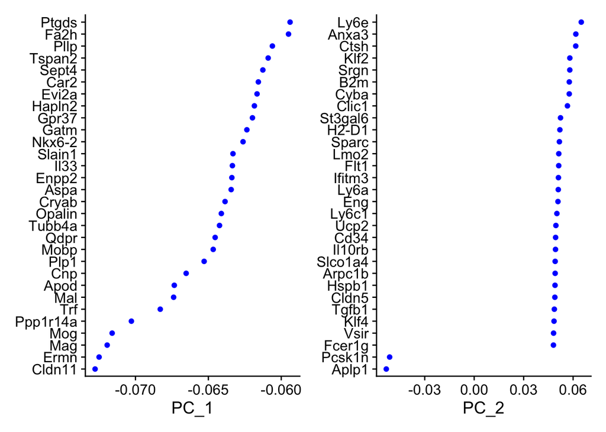

```r
# PCA
sc_seurat_obj <- RunPCA(sc_seurat_obj, verbose=FALSE)
VizDimLoadings(sc_seurat_obj, dims = 1:2, reduction = "pca")
```

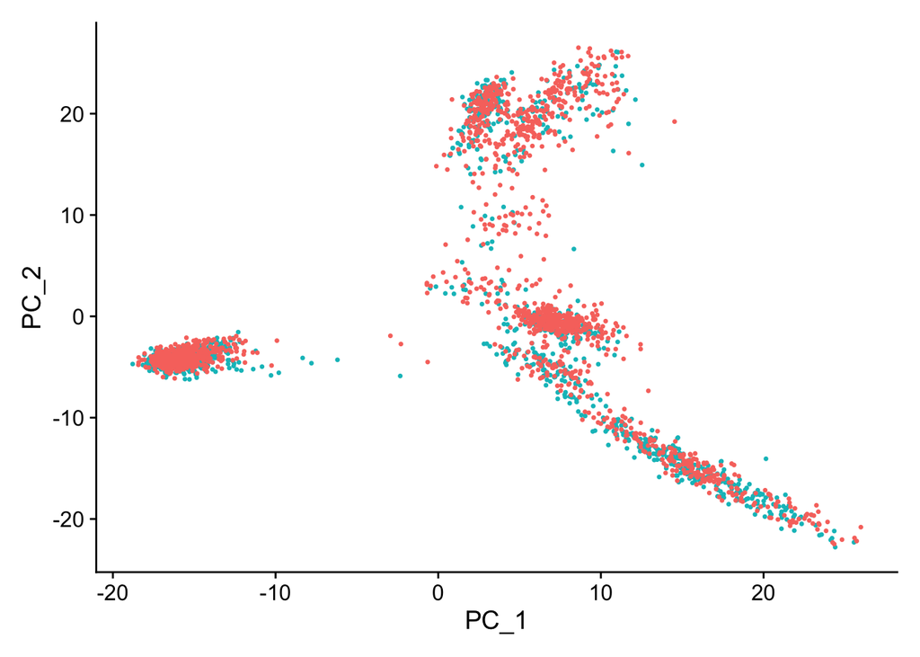

```r
DimPlot(sc_seurat_obj, reduction = "pca") + NoLegend()
```

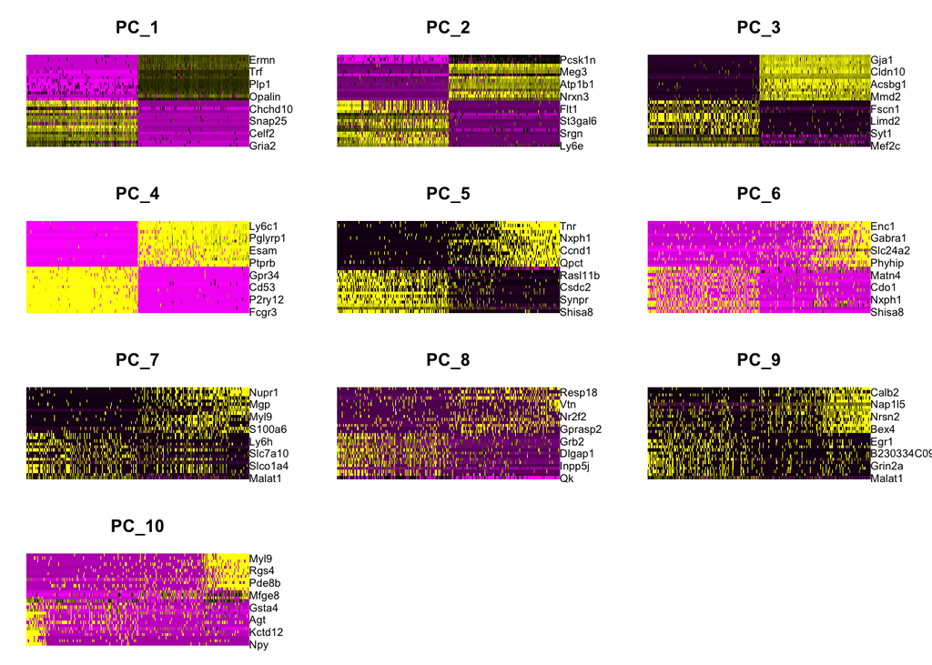

```r
DimHeatmap(sc_seurat_obj, dims = 1:10, cells = 500, balanced = TRUE)
```

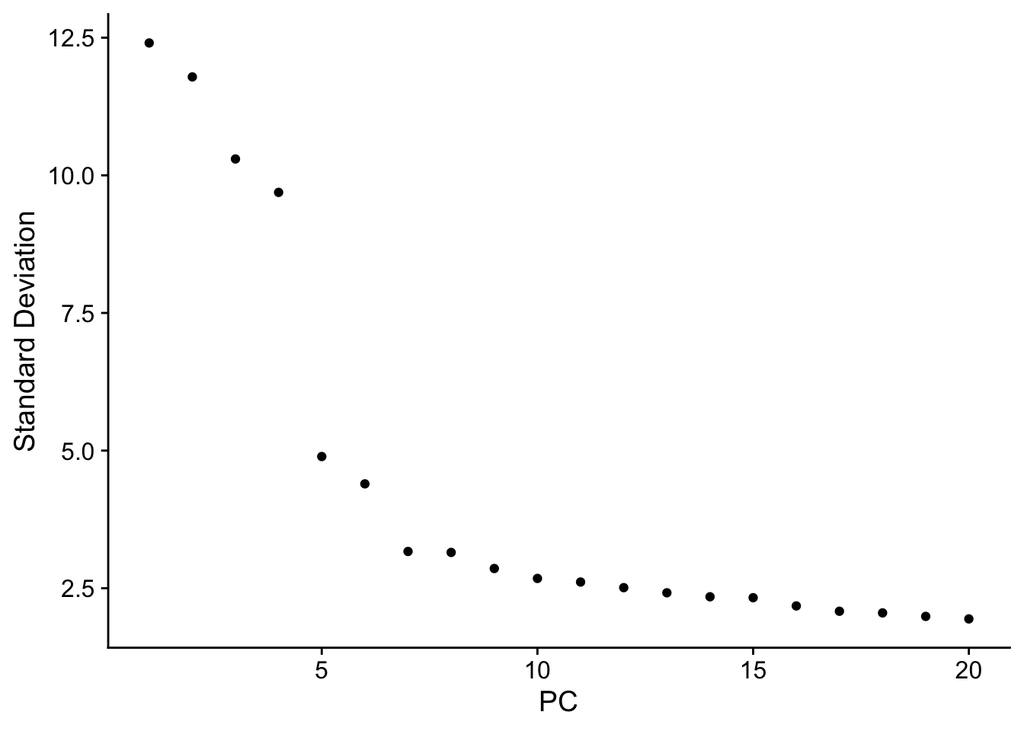

```r
ElbowPlot(sc_seurat_obj)
```

```r
# Clustering
sc_seurat_obj <- FindNeighbors(sc_seurat_obj, dims = 1:10)
sc_seurat_obj <- FindClusters(sc_seurat_obj, resolution = 0.025)
```

```
## Modularity Optimizer version 1.3.0 by Ludo Waltman and Nees Jan van Eck
##
## Number of nodes: 2931
## Number of edges: 97041
##
## Running Louvain algorithm...
## Maximum modularity in 10 random starts: 0.9937
## Number of communities: 6
## Elapsed time: 0 seconds
```

```r
# find marker genes of each cluster
cluster_markers <- FindAllMarkers(sc_seurat_obj, only.pos = TRUE, min.pct = 0.25, logfc.threshold = 0.25, verbose = FALSE)
```

[output not shown]

```r
# choose top marker
top_markers <- cluster_markers %>%
  group_by(cluster) %>%
  top_n(n = 10, wt = avg_log2FC)

top_genes <- top_markers %>% group_by(cluster) %>% top_n(n = 5, wt = avg_log2FC)
#FeaturePlot(sc_seurat_obj, features = unique(top_genes$gene), cols = c("blue", "red"), reduction = "tsne")

new_cluster_ids <- c("CellType1", "CellType2", "CellType3", "CellType4", "CellType5", "CellType6")
names(new_cluster_ids) <- levels(sc_seurat_obj)
sc_seurat_obj <- RenameIdents(sc_seurat_obj, new_cluster_ids)

# bulk signature matrix
average_expression <- AverageExpression(sc_seurat_obj)
```

```
## As of Seurat v5, we recommend using AggregateExpression to perform pseudo-bulk analysis.
```

```r
bulk_signature_matrix <- average_expression$RNA

head(bulk_signature_matrix)
```

```
## 6 x 6 sparse Matrix of class "dgCMatrix"
##           CellType1  CellType2   CellType3  CellType4  CellType5 CellType6
## Sox17   0.007098499 0.04946768 0.008797571 5.87056005 0.03519064 .
## Mrpl15  0.785016347 1.27775229 0.850610239 1.00260087 1.16316468 0.9736278
## Lypla1  0.511008341 0.79224327 0.532664894 0.99712555 0.98537447 0.5917463
## Tcea1   1.295726505 1.04054874 1.003208501 1.32072542 0.92234978 1.2661495
## Rgs20   0.051042227 2.13839720 0.434447441 0.07072141 .          0.5036883
## Atp6v1h 0.840131906 0.91241426 1.490793849 0.62345006 1.01080326 1.0870432
```

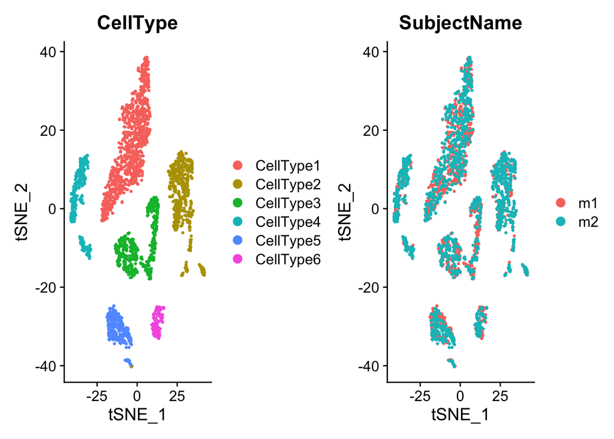

```r
write.csv(bulk_signature_matrix, "/Users/ziyiou/CUHKSZ/23 Fall/Genomics/longitudinal analysis/signature_matrix bulk.csv")

# sc signature matrix
cell_ids <- colnames(sc_seurat_obj)
cluster_ids <- sc_seurat_obj$seurat_clusters
cell_types <- sc_seurat_obj@active.ident

pheno_sc_data <- data.frame(
  CellID = cell_ids,
  ClusterID = cluster_ids,
  CellType = cell_types,
  stringsAsFactors = FALSE
)

pheno_sc_data$SubjectName <- ifelse(pheno_sc_data$CellID %in% colnames(m1), "m1",
                                     ifelse(pheno_sc_data$CellID %in% colnames(m2), "m2", NA))
sc_seurat_obj$SubjectName <- pheno_sc_data$SubjectName
sc_seurat_obj$CellType <- pheno_sc_data$CellType

# Visualization
sc_seurat_obj <- RunTSNE(sc_seurat_obj, dims = 1:10)
DimPlot(sc_seurat_obj, reduction = "tsne", group.by = c("CellType", "SubjectName"))
```

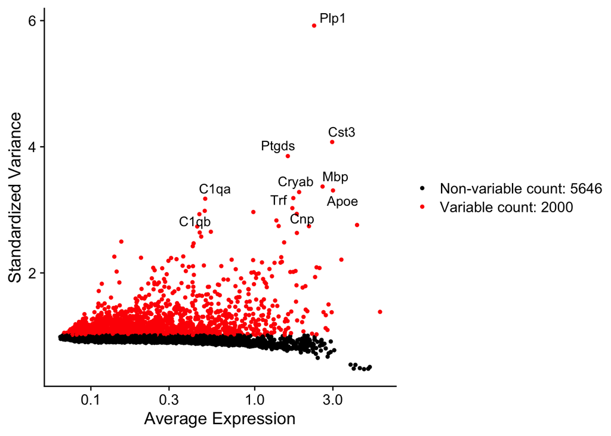

```r
# find variable feature (top 2,000)
markers <- VariableFeatures(sc_seurat_obj)
marker_distrib <- data.frame(genes = character(length(VariableFeatures(sc_seurat_obj))))
marker_distrib$genes <- VariableFeatures(sc_seurat_obj)

variable_gene_plot <- VariableFeaturePlot(sc_seurat_obj)
variable_gene_plot_with_label <- LabelPoints(plot= variable_gene_plot,
            points = head(VariableFeatures(sc_seurat_obj), 10),
            repel=TRUE, xnudge = 0, ynudge = 0)
variable_gene_plot_with_label
```

## 2.2 Cell type deconvolution

Here we apply `MuSiC` for cell type deconvolution.

```r
C = sc_data
T = exprs_data
pDataC = pheno_sc_data

    ##########    MATRIX DIMENSION APPROPRIATENESS    ##########
keep = intersect(rownames(C),rownames(T))
C = C[keep,]
T = T[keep,]


C.eset <- Biobase::ExpressionSet(assayData = as.matrix(C),phenoData = Biobase::AnnotatedDataFrame(pDataC))
T.eset <- Biobase::ExpressionSet(assayData = as.matrix(T))


C.eset <- SingleCellExperiment(assays = list(counts = as.matrix(C)))
colData(C.eset) <- DataFrame(assigned_cluster = pDataC$CellType, SubjectName = rownames(pDataC))

RESULTS = t(MuSiC::music_prop(bulk.mtx = exprs(T.eset), sc.sce = C.eset,
                    clusters = 'assigned_cluster',
                    markers = NULL,
                    normalize = FALSE,
                    samples = 'SubjectName',
                    verbose = F)$Est.prop.weighted)

head(RESULTS[, 1:5])
```

```
##            B2_1_9F_WT  B2_4_9M_WT  B2_5_9M_WT   B2_6_9M_WT B2_7_12F_WT
## CellType5 0.000000000 0.000000000 0.000000000 0.0000000000 0.000000000
## CellType2 0.124287979 0.104639332 0.095537846 0.1217307506 0.084769613
## CellType1 0.027255769 0.019428395 0.006645787 0.0311514495 0.009592542
## CellType6 0.004309373 0.000000000 0.000000000 0.0011624426 0.000000000
## CellType3 0.844146879 0.872755857 0.892504390 0.8453870913 0.905637844
## CellType4 0.000000000 0.003176415 0.005311977 0.0005682659 0.000000000
```

# 3. ISLET

## 3.1 Overview of ISLET

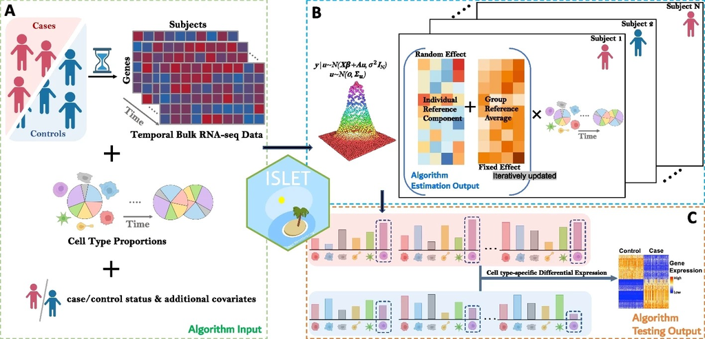

An overview of our proposed method ISLET (Individual Specific celL typE referencing Tool). **A** ISLET takes repeatedly measured bulk RNA-seq data, cell type proportions (known or estimated), and disease status as the algorithm input. Additional covariates are optional. **B** By a hierarchical mixed-effect modeling, ISLET can iteratively retrieve individual-specific and cell-type-specific gene expression reference panels. The fixed effect is the group-level average and the random effect is the individual-level deviance from the group mean. **C** Given the individual-specific reference panel, ISLET can conduct test to identify cell-type-specific differentially expressed genes (csDEG)

ISLET is formulated as a mixed-effect regression model:
$$y = X\beta + Au + \epsilon$$

## 3.2 Data preparation

ISLET needs one input file organized into `SummarizedExperiment` objects, combining cases and controls. So we first convert data into SummarizedExperiment objects.

```r
######### colData:  sample meta-data & input cell type proportions #######

### proportion
proportion <- data.frame(t(RESULTS))
rownames(proportion) <- pdata$geo_accession

### meta-data
pheno_bulk_data <- read.csv("/Users/ziyiou/CUHKSZ/23 Fall/Genomics/longitudinal analysis/sample_pheno_data.csv", sep=",", row.names = 1)
sample_info <- data.frame(group = ifelse(pdata$`genotype:ch1` == "B6;129S1/SvImJ", "ctrl",
                      ifelse(pdata$`genotype:ch1` == "3xTg-AD", "case", NA)),
                      subject_ID = pheno_bulk_data$subject_ID,
                      CellType1 = proportion$CellType1,
                      CellType2 = proportion$CellType2,
                      CellType3 = proportion$CellType3,
                      CellType4 = proportion$CellType4, # No CellType5
                      CellType6 = proportion$CellType6
                      )

sample_info_age <- data.frame(group = ifelse(pdata$`genotype:ch1` == "B6;129S1/SvImJ", "ctrl",
                      ifelse(pdata$`genotype:ch1` == "3xTg-AD", "case", NA)),
                      subject_ID = pheno_bulk_data$subject_ID,
                          age = as.numeric(pdata$`age (months):ch1`),
                      CellType1 = proportion$CellType1,
                      CellType2 = proportion$CellType2,
                      CellType3 = proportion$CellType3,
                      CellType4 = proportion$CellType4, # No CellType5
                      CellType6 = proportion$CellType6
                      )

sample_info_age_sex <- data.frame(group = ifelse(pdata$`genotype:ch1` == "B6;129S1/SvImJ", "ctrl",
                      ifelse(pdata$`genotype:ch1` == "3xTg-AD", "case", NA)),
                      subject_ID = pheno_bulk_data$subject_ID,
                          age = as.numeric(pdata$`age (months):ch1`),
                          sex = ifelse(pdata$`Sex:ch1` == "Female", 0,
                      ifelse(pdata$`Sex:ch1` == "Male", 1, NA)),
                      # 0 for female, 1 for male
                      CellType1 = proportion$CellType1,
                      CellType2 = proportion$CellType2,
                      CellType3 = proportion$CellType3,
                      CellType4 = proportion$CellType4, # No CellType5
                      CellType6 = proportion$CellType6
                      )
rownames(sample_info) = pdata$geo_accession
rownames(sample_info_age) = pdata$geo_accession
rownames(sample_info_age_sex) = pdata$geo_accession


sample_info <- sample_info %>% arrange(group)
sample_info_age <- sample_info_age %>% arrange(group)
sample_info_age_sex <- sample_info_age_sex %>% arrange(group)

######### counts: gene expression value data frame #########
counts = T
colnames(counts) = pdata$geo_accession
sorted_row_names <- rownames(sample_info)
counts <- data.frame(counts[ , sorted_row_names])
```

```r
mice_se <- SummarizedExperiment(
    assays = list(counts = counts),
    colData = sample_info)
# unique(colData(mice_se)$group)[1]

mice_se_age <- SummarizedExperiment(
    assays = list(counts = counts),
    colData = sample_info_age)

mice_se_age_sex <- SummarizedExperiment(
    assays = list(counts = counts),
    colData = sample_info_age_sex)
```

```r
# for mean
input1 <- dataPrep(dat_se = mice_se)
```

```
## Begin: working on data preparation as the input for ISLET algorithm.
```

```
## Complete: data preparation for ISLET.
```

```r
input1
```

```
## First couple of elements from cases and controls:
##        GSM8061519 GSM8061520 GSM8061521 GSM8061522 GSM8061523 GSM8061524
## Sox17          47         57        234        190        114        315
## Mrpl15        374        498        986        910        560       1227
## Lypla1        364        484        961        849        550       1156
##        GSM8061509 GSM8061510 GSM8061511 GSM8061512 GSM8061513 GSM8061514
## Sox17          16         41         43         62         85         61
## Mrpl15         95        213        380        369        417        353
## Lypla1        139        232        333        362        388        359
## Design matrices hidded.
## Total cell type number:
## [1] 5
## Cell type categories:
## [1] "CellType1" "CellType2" "CellType3" "CellType4" "CellType6"
## Total sample number and subject number:
## [1] 77 17
## Total case number and ctrl number:
## [1] 11  6
## First several subject ID for the samples:
##  [1] 111 112 113 211 212 213 111 112 113 111
## Data preparation type (intercept/slope):
## [1] "intercept"
```

```r
# for slope(age)
input2 <- dataPrepSlope(dat_se = mice_se_age)
```

```
## Begin: working on data preparation as the input for ISLET algorithm.
## Complete: data preparation for ISLET.
```

```r
input2
```

```
## First couple of elements from cases and controls:
##        GSM8061519 GSM8061520 GSM8061521 GSM8061522 GSM8061523 GSM8061524
## Sox17          47         57        234        190        114        315
## Mrpl15        374        498        986        910        560       1227
## Lypla1        364        484        961        849        550       1156
##        GSM8061509 GSM8061510 GSM8061511 GSM8061512 GSM8061513 GSM8061514
## Sox17          16         41         43         62         85         61
## Mrpl15         95        213        380        369        417        353
## Lypla1        139        232        333        362        388        359
## Design matrices hidded.
## Total cell type number:
## [1] 5
## Cell type categories:
## [1] "CellType1" "CellType2" "CellType3" "CellType4" "CellType6"
## Total sample number and subject number:
## [1] 77 17
## Total case number and ctrl number:
## [1] 11  6
## First several subject ID for the samples:
##  [1] 111 112 113 211 212 213 111 112 113 111
## Data preparation type (intercept/slope):
## [1] "slope"
```

## 3.3 Deconvolve individual-specific reference panel

With the curated data `input1` from the previous step, now we can use `ISLET` to conduct deconvolution and obtain the individual-specific and cell-type-specific reference panels. This process can be achieved by running:

```r
res.sol <- isletSolve(input=input1)
```

The total running time of `isletSolve` here is 6 min.

The `res.sol` is the deconvolution result list. For both case and control group, the deconvolution result is a list of length K, where K is the number of cell types. For each of the K elements, it is a matrix of dimension G by N. For each of the K cell types, it stores the deconvoluted values in a feature (G) by subject (N) matrix.

```r
#View the deconvolution results
caseVal <- caseEst(res.sol)
ctrlVal <- ctrlEst(res.sol)
#length(caseVal) #For cases, a list of 11 cell types' matrices.
#length(ctrlVal) #For controls, a list of 6 cell types' matrices.

## view the reference panels for CellType1,
## for the first 5 genes and first 4 subjects, in Case group.
caseVal$CellType1[1:5, 1:4]
```

```
##             111      112      113      211
## Sox17  942.9757 933.8266 934.9644 933.7188
## Mrpl15 670.8150 631.0751 628.9121 629.3699
## Lypla1   0.0000   0.0000   0.0000   0.0000
## Tcea1    0.0000   0.0000   0.0000   0.0000
## Rgs20    0.0000   0.0000   0.0000   0.0000
```

```r
## view the reference panels for CellType1,
## for the first 5 genes and first 4 subjects, in Control group.
ctrlVal$CellType1[1:5, 1:4]
```

```
##             101      201      202      203
## Sox17  879.9635 878.7956 879.7016 881.7183
## Mrpl15   0.0000   0.0000   0.0000   0.0000
## Lypla1   0.0000   0.0000   0.0000   0.0000
## Tcea1    0.0000   0.0000   0.0000   0.0000
## Rgs20    0.0000   0.0000   0.0000   0.0000
```

```r
caseVal$CellType2[1:5, 1:4]
```

```
##              111       112       113      211
## Sox17   271.2604  226.5422  231.8662  221.723
## Mrpl15 2224.2755 2064.4477 2060.0762 2045.434
## Lypla1 2489.9454 2345.1064 2335.5704 2331.201
## Tcea1  2962.5632 2777.4387 2769.5472 2756.142
## Rgs20  2920.1286 2788.2625 2770.3969 2771.743
```

```r
ctrlVal$CellType2[1:5, 1:4]
```

```
##               101        201        202       203
## Sox17    59.84658   55.68339   62.16929   69.2877
## Mrpl15 6475.62118 6454.04073 6521.54302 6541.8034
## Lypla1 8134.00263 8126.18961 8190.58366 8187.3240
## Tcea1  8919.21163 8899.78973 8976.69670 8982.6676
## Rgs20  1925.98349 1912.50335 1976.13643 1970.4521
```

```r
caseVal$CellType3[1:5, 1:4]
```

```
##              111       112       113        211
## Sox17   76.67076   0.00000  9.312171  0.0000000
## Mrpl15 525.23080 102.30957 96.625406 31.3925252
## Lypla1 440.03449  69.40789 69.761571  0.6738074
## Tcea1  569.23061 112.89709 85.677821 18.8769454
## Rgs20  423.70646 103.89650 94.259145 43.9711318
```

```r
ctrlVal$CellType3[1:5, 1:4]
```

```
##              101       201       202       203
## Sox17   48.47799  41.84864  62.27806  81.09662
## Mrpl15   0.00000   0.00000   0.00000  43.10528
## Lypla1   0.00000   0.00000   0.00000   0.00000
## Tcea1    0.00000   0.00000   0.00000   0.00000
## Rgs20  134.33541 142.39190 348.31048 331.39772
```

```r
caseVal$CellType4[1:5, 1:4]
```

```
##             111      112      113      211
## Sox17  4139.768 4136.531 4136.391 4135.866
## Mrpl15 3698.565 3685.421 3685.981 3684.837
## Lypla1 5284.767 5273.334 5272.713 5272.623
## Tcea1  6719.214 6703.396 6704.203 6702.439
## Rgs20     0.000    0.000    0.000    0.000
```

```r
ctrlVal$CellType4[1:5, 1:4]
```

```
##             101      201      202      203
## Sox17  204.1285 204.5195 204.0611 204.0382
## Mrpl15   0.0000   0.0000   0.0000   0.0000
## Lypla1   0.0000   0.0000   0.0000   0.0000
## Tcea1    0.0000   0.0000   0.0000   0.0000
## Rgs20    0.0000   0.0000   0.0000   0.0000
```

```r
caseVal$CellType6[1:5, 1:4]
```

```
##              111       112       113       211
## Sox17      0.000     0.000     0.000     0.000
## Mrpl15  7346.362  7340.021  7340.443  7340.397
## Lypla1 11129.727 11124.459 11123.743 11123.636
## Tcea1   9125.991  9117.204  9116.366  9116.263
## Rgs20   8153.730  8149.831  8150.923  8151.098
```

```r
ctrlVal$CellType6[1:5, 1:4]
```

```
##        101 201 202 203
## Sox17    0   0   0   0
## Mrpl15   0   0   0   0
## Lypla1   0   0   0   0
## Tcea1    0   0   0   0
## Rgs20    0   0   0   0
```

## 3.4 Test cell-type-specific differential expression (csDE) in mean (intercept): test the group effect on individual reference panels

Now we can test the group effect on individual reference panels, i.e., identifying csDE genes in mean or intercept. In this ‘intercept test’, we assume that the individual-specific reference panel is unchanged across time points. Note that the deconvolution in section **3.3** can be skipped, if one only need to call csDE genes.

The result `res.test` is a matrix of p-values, in the dimension of feature by cell type. Each element is the LRT p-value, by contrasting case group and control group, for one feature in one cell type.

Total running time of `isletTest`: 40 min

```r
#Test for csDE genes
res.test <- isletTest(input=input1)
```

```
## csDE testing on cell type 1
## csDE testing on cell type 2
## csDE testing on cell type 3
## csDE testing on cell type 4
## csDE testing on cell type 5
## csDE testing on 5 cell types finished
```

```r
rownames(res.test) = rownames(counts)
head(res.test)
```

```
##         CellType1 CellType2 CellType3 CellType4   CellType6
## Sox17   0.9739587 0.8742497 0.5590161 0.2674415 0.230614057
## Mrpl15  0.6010524 0.3012671 0.4608129 0.3635854 0.006702449
## Lypla1  0.3923427 0.1493014 0.3010296 0.3481377 0.006104315
## Tcea1   0.5844157 0.2148199 0.3283420 0.2674615 0.009565976
## Rgs20   0.6290600 0.8190236 0.7685433 0.5196070 0.062138730
## Atp6v1h 1.0000000 0.5855284 0.7155203 0.3996974 0.023733587
```

## 3.5 Test csDE in change-rate (slope):

Given an additional continuous variable such as time or age, ISLET is able to compare cases and controls in the change-rate of reference profile over time. This is the ‘slope test’. Here, the assumption is that for the participants or subjects in a group, the individual reference profile could change over time, with change-rate fixed by group. At a given time point, there may be no (significant) group effect in the reference panel, but the participants still have distinct underlying reference profiles. Under this setting, it is of interest to test for such difference. Below is an example to detect reference panel change-rate difference between two groups, from data preparation to test.

The result `age.test` is a matrix of p-values, in the dimension of feature by cell type. Each element is the LRT p-value, by contrasting case group and control group, for one feature in one cell type. In contrast to the (intercept) test described before, here is a test for difference of the expression CHANGE IN REFERENCE over time, between cases and controls.

Total running time of `isletTest`: 32 min

```r
age.test <- isletTest(input = input2)
```

```
## csDE testing on cell type 1
## csDE testing on cell type 2
## csDE testing on cell type 3
## csDE testing on cell type 4
## csDE testing on cell type 5
## csDE testing on 5 cell types finished
```

```r
rownames(age.test) = rownames(counts)
head(age.test)
```

```
##          CellType1  CellType2 CellType3  CellType4 CellType6
## Sox17   0.43370628 0.67164254 0.9350649 0.23935867 0.5571554
## Mrpl15  0.04750965 0.10736850 0.3354242 0.20307043 0.2574608
## Lypla1  0.02414077 0.03712998 0.1239379 0.16744715 0.3508589
## Tcea1   0.01082938 0.02689315 0.1218708 0.10323571 0.9002814
## Rgs20   0.07129821 0.10428011 0.3389987 0.10604597 0.8599768
## Atp6v1h 0.01566272 0.02732087 0.1215449 0.07557469 0.5077357
```

## 3.6 imply: improving cell-type deconvolution accuracy using personalized reference profiles

Total running time of `imply`: 3 min

```r
dat <- implyDataPrep(sim_se = mice_se)
```

```
## Begin: working on data preparation as the input for imply.
```

```
## Complete: data preparation for imply.
```

```r
#Use imply for deconvolution
result <- imply(dat)
```

```
## Personalized Panel recovered by lmer.
```

```
## Personalized deconvolution done!
```

```r
#View the subject-specific and cell-type-specific reference panels solved
#by linear mixed-effect models of the first subject
result$p.ref[,,1]
```

```
##                  CellType1    CellType2    CellType3    CellType4    CellType6
## Sox17         1.570374e+03 0.000000e+00 7.874794e+01 4.973249e+03 0.000000e+00
## Mrpl15        2.835107e+03 6.278123e+02 2.768800e+02 1.066841e+04 0.000000e+00
## Lypla1        2.088577e+03 4.141037e+02 2.894576e+02 1.462418e+04 5.186478e+03
## Tcea1         2.428365e+03 0.000000e+00 4.648724e+02 1.872010e+04 1.523276e+03
## Rgs20         0.000000e+00 2.016753e+03 1.967838e+02 0.000000e+00 1.530120e+03
## Atp6v1h       0.000000e+00 4.555181e+03 1.363932e+03 3.625222e+04 0.000000e+00
## Rb1cc1        3.816681e+03 9.607024e+03 1.541545e+03 5.476227e+04 0.000000e+00
## St18          9.256039e+03 0.000000e+00 7.428252e+02 6.154287e+04 0.000000e+00
## Pcmtd1        0.000000e+00 1.021204e+04 1.516239e+03 3.022988e+04 0.000000e+00
## Rrs1          0.000000e+00 1.244388e+03 0.000000e+00 6.107424e+01 0.000000e+00
## Vcpip1        1.070115e+04 5.438141e+03 1.765100e+03 6.909090e+04 1.661113e+03
## Sgk3          0.000000e+00 1.517408e+03 4.011759e+02 7.391791e+03 0.000000e+00
## Snhg6         0.000000e+00 2.296215e+02 5.731362e+01 7.331582e+02 0.000000e+00
## Cops5         9.789153e+02 7.782701e+02 6.127077e+02 1.869271e+04 0.000000e+00
## Cspp1         7.078413e+02 1.773141e+03 1.113548e+03 5.580270e+03 1.189064e+04
## Arfgef1       4.982456e+03 7.343680e+03 2.412420e+03 6.905740e+04 0.000000e+00
## Prex2         0.000000e+00 1.022759e+04 1.226434e+03 7.690493e+04 0.000000e+00
## Ncoa2         2.521687e+03 8.381315e+03 2.092416e+03 8.743234e+04 0.000000e+00
## Tram1         3.599220e+03 2.775760e+03 4.161577e+02 3.029669e+04 2.246314e+03
## Kcnb2         5.765127e+03 2.074999e+03 8.438778e+02 1.196962e+04 0.000000e+00
## Terf1         1.064493e+03 6.645347e+02 1.571485e+02 8.559813e+03 0.000000e+00
## Rpl7          1.013683e+04 0.000000e+00 1.263375e+03 5.339880e+04 0.000000e+00
## Stau2         4.348104e+03 1.065884e+04 1.170541e+03 2.048355e+04 0.000000e+00
## Ube2w         0.000000e+00 5.024361e+03 4.555139e+02 2.982084e+03 4.581528e+03
## Tmem70        0.000000e+00 2.218686e+03 1.474408e+02 1.350212e+03 9.520415e+02
## Gdap1         5.442476e+03 9.080059e+03 7.830832e+02 3.114885e+04 0.000000e+00
## Paqr8         1.244930e+04 2.664245e+04 0.000000e+00 9.326390e+04 7.279020e+03
## Tmem14a       0.000000e+00 1.007099e+03 1.767695e+02 2.727624e+03 0.000000e+00
## Ogfrl1        0.000000e+00 1.396578e+04 1.550780e+03 5.192319e+04 0.000000e+00
## Smap1         2.362054e+03 3.176919e+03 1.454232e+03 3.611111e+04 0.000000e+00
## Sdhaf4        5.904449e+02 0.000000e+00 1.327261e+02 4.292833e+03 0.000000e+00
## Lmbrd1        2.169146e+04 3.429697e+03 2.829441e+03 1.209865e+05 0.000000e+00
## Adgrb3        0.000000e+00 1.060626e+04 3.978386e+03 3.129284e+04 4.095704e+03
## Phf3          5.624170e+03 8.342318e+03 1.409599e+03 4.451625e+04 0.000000e+00
## Ptp4a1        3.758491e+02 1.092932e+02 1.645661e+01 8.972111e+02 0.000000e+00
## Rab23         3.138242e+03 1.601193e+03 3.636108e+02 1.553496e+04 0.000000e+00
## Zfp451        5.228780e+03 5.284162e+03 1.984090e+03 5.855481e+04 2.858928e+03
## Dst           1.483658e+05 3.438322e+04 8.731327e+03 4.549122e+05 0.000000e+00
## Ccdc115       0.000000e+00 4.304587e+02 6.260179e+01 2.452292e+03 0.000000e+00
```

[output cut: 7161 more lines]

```
## Csf2ra        0.000000e+00 2.542582e+03 5.218442e+01 0.000000e+00 0.000000e+00
## mt-Nd1        0.000000e+00 7.952783e+05 7.761131e+04 0.000000e+00 3.041548e+06
## mt-Nd2        0.000000e+00 7.090563e+05 9.962866e+03 0.000000e+00 2.228547e+06
## mt-Co1        2.854176e+05 1.402658e+06 9.859759e+04 1.400830e+06 2.145544e+06
## mt-Co2        0.000000e+00 6.195915e+02 1.476397e+02 1.497338e+03 4.511107e+03
## mt-Atp8       0.000000e+00 1.353731e+02 3.345879e+01 0.000000e+00 1.733800e+03
## mt-Atp6       0.000000e+00 6.238632e+02 1.394960e+02 1.210999e+03 5.906658e+03
## mt-Co3        0.000000e+00 4.407695e+02 1.151437e+02 7.410234e+02 2.418599e+03
## mt-Nd3        0.000000e+00 1.588630e+03 3.702156e+01 3.247565e+01 6.293972e+03
## mt-Nd4l       0.000000e+00 1.598210e+02 1.681225e+01 3.780849e+02 7.095082e+02
## mt-Nd4        0.000000e+00 5.797381e+05 1.424078e+04 0.000000e+00 1.556694e+06
## mt-Nd5        0.000000e+00 7.882940e+05 2.342695e+04 7.873070e+05 2.023110e+06
## mt-Nd6        0.000000e+00 1.348986e+04 8.855953e+02 0.000000e+00 1.648127e+04
## mt-Cytb       0.000000e+00 9.133322e+05 1.989330e+04 0.000000e+00 1.778460e+06
## Vamp7         0.000000e+00 3.878549e+03 1.033095e+02 8.733924e+03 7.370080e+03
```

```r
#View the improved cell deconvolution results
head(result$imply.prop)
```

```
##            CellType1  CellType2 CellType3 CellType4 CellType6
## GSM8061519         0 0.17601988 0.8239801         0         0
## GSM8061525         0 0.14275058 0.8572494         0         0
## GSM8061540         0 0.12070890 0.8792911         0         0
## GSM8061550         0 0.18734309 0.8126569         0         0
## GSM8061557         0 0.09449514 0.9055049         0         0
## GSM8061559         0 0.09404689 0.9059531         0         0
```

```r
tail(result$imply.prop)
```

```
##             CellType1  CellType2 CellType3   CellType4 CellType6
## GSM8061585 0.04582312 0.06663584 0.8770133 0.010527749         0
## GSM8061515 0.05141968 0.05579657 0.8921276 0.000656207         0
## GSM8061530 0.02576074 0.05090020 0.9101617 0.013177323         0
## GSM8061536 0.06277544 0.05887461 0.8665768 0.011773161         0
## GSM8061544 0.04925716 0.03383891 0.9149112 0.001992736         0
## GSM8061581 0.03684328 0.05690089 0.8969992 0.009256611         0
```

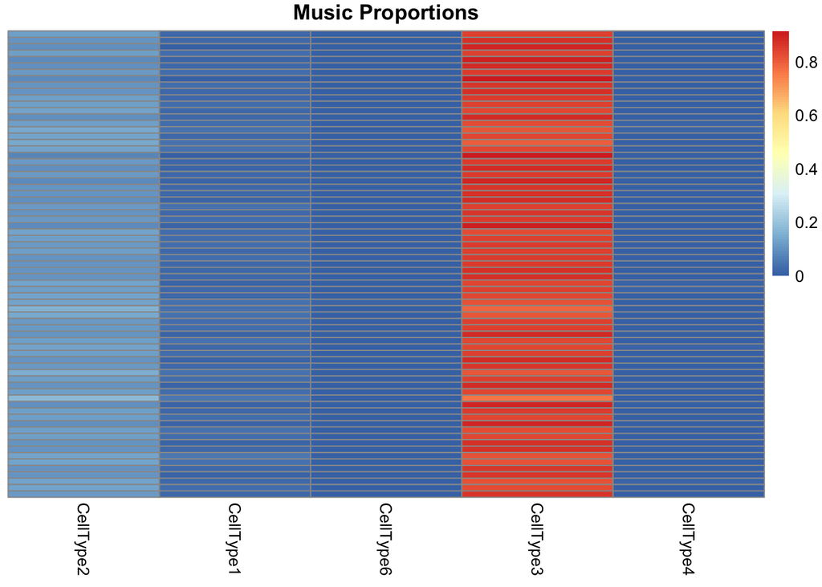

```r
music_prop <- proportion[, -1]
islet_prop <- result$imply.prop


common_rownames <- intersect(rownames(music_prop), rownames(islet_prop))
music_prop <- music_prop[common_rownames, ]
islet_prop <- islet_prop[common_rownames, ]

common_colnames <- intersect(colnames(music_prop), colnames(islet_prop))
music_prop <- music_prop[ , common_colnames]
islet_prop <- islet_prop[ , common_colnames ]

heatmap_music <- pheatmap(music_prop, main = "Music Proportions", cluster_rows = F, cluster_cols = F,
         show_rownames = F)
```

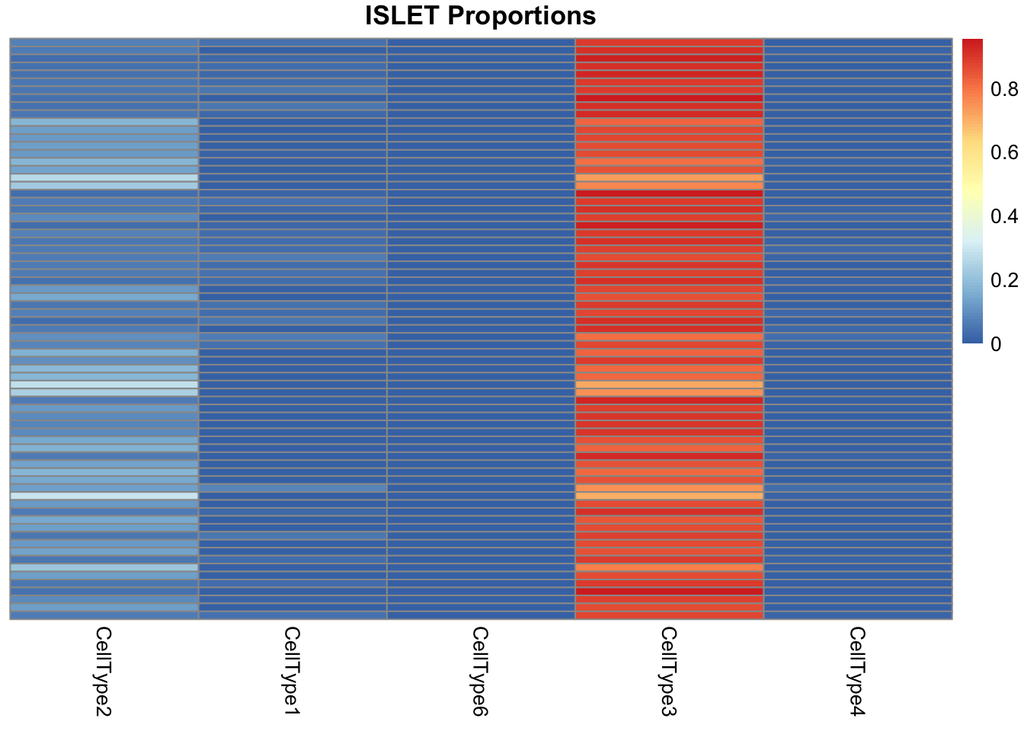

```r
heatmap_islet <- pheatmap(islet_prop, main = "ISLET Proportions", cluster_rows = F, cluster_cols = F,
         show_rownames = F)
```

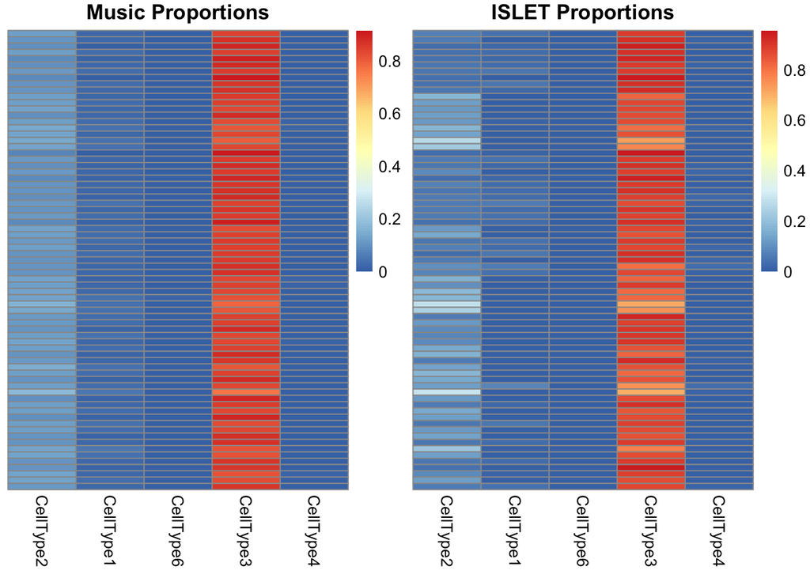

```r
grid.arrange(
  heatmap_music$gtable,
  heatmap_islet$gtable,
  ncol = 2
)
```

# 4. Gene Sets Enrichment Analysis (GSEA)

## 4.1 Top 20 variable genes in the bulk sample

Here we are interested in the top 20 variable genes in the bulk sample.

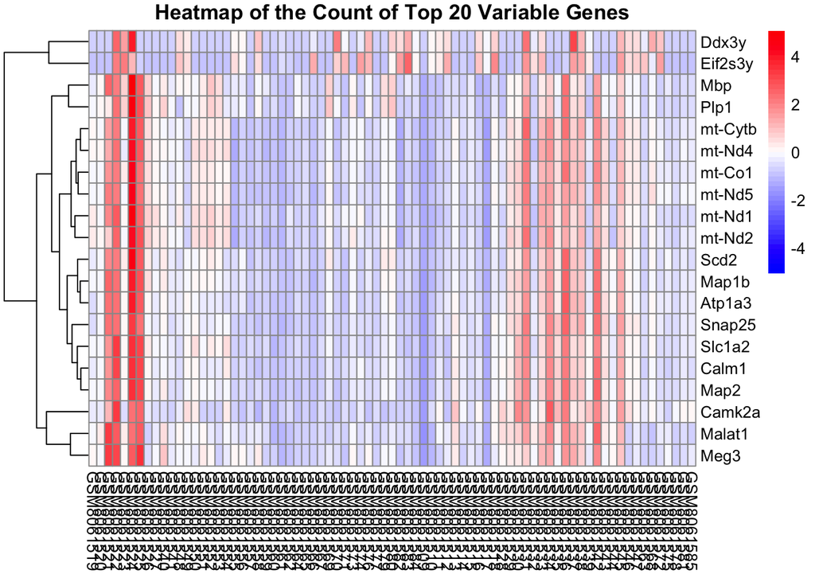

```r
gene_variability <- apply(counts, 1, sd)
variability_df <- data.frame(gene = rownames(counts), variability = gene_variability)
# sort according to variablity
variability_df <- variability_df[order(variability_df$variability, decreasing = TRUE), ]
top20_genes <- head(variability_df$gene, 20)
custom_gene_set <- list(
  "top20_variable_genes" = top20_genes
)
top20_counts <- counts[top20_genes, ]

pheatmap(
  top20_counts,
  cluster_rows = TRUE,     # 是否对基因进行聚类
  cluster_cols = F,     # 是否对样本进行聚类
  scale = "row",           # 对行进行标准化
  color = colorRampPalette(c("blue", "white", "red"))(50), # 热图颜色
  main = "Heatmap of the Count of Top 20 Variable Genes"
)
```

## 4.2 csDEG detected by ISLET

We convert the $\mathrm{p-value}$ acquired in the above section **3.5** into -log10 scale since the small p-values are essential in csDEG calling. The more significant the gene is, the bigger $-log_{10}(\mathrm{p-value})$ is. We visualize it by a heatmap.

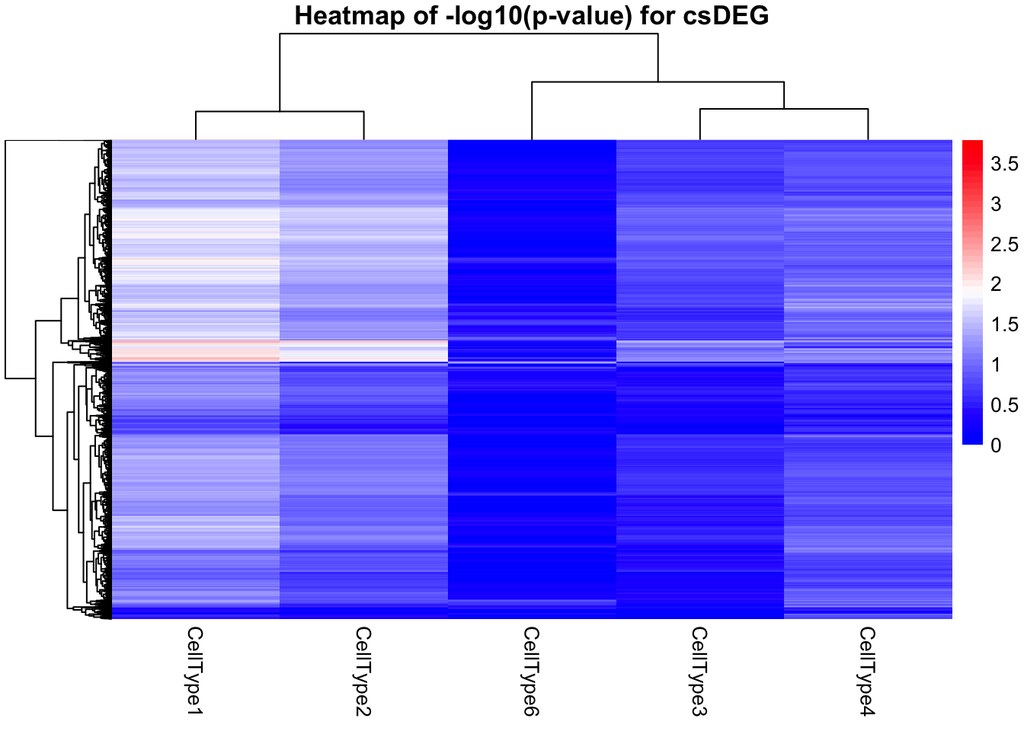

```r
#significant_gene_matrix <- age.test[rownames(age.test) %in% unlist(csDEG_list), ]

pheatmap(-log10(age.test),
         cluster_rows = TRUE,
         cluster_cols = TRUE,
         color = colorRampPalette(c("blue", "white", "red"))(50),
         show_rownames = F,
         main = "Heatmap of -log10(p-value) for csDEG")
```

We used BH procedure to control FDR in multiple testing, and then reported csDEG at FDR < 0.25. (In the `ISLET` paper, the author reported csDEG at FDR < 0.1, but here all the FDR we get is above 0.2, so we report csDEG at FDR < 0.25)

Given that there are so many genes reported, we only explore the top 50 genes with least p-value, meaning that they are the most significant. We want to be stringent with the csDEGs, so we only keep csDEG that appear in only one cell type.

```r
p_values_long <- as.data.frame(as.table(age.test))
colnames(p_values_long) <- c("Gene", "CellType", "PValue")
p_values_long$FDR <- p.adjust(p_values_long$PValue, method = "BH")

csDEG <- p_values_long %>%
  filter(FDR < 0.25)


top_csDEG <- csDEG %>%
  group_by(CellType) %>%
  arrange(CellType, PValue) %>%
  slice_head(n = 50) %>%
  ungroup()

gene_list_by_celltype <- top_csDEG %>%
  split(.$CellType) %>%
  lapply(function(df) df$Gene)

#gene_list_by_celltype
```

```r
# 计算 -log(p-value)
top_csDEG <- top_csDEG %>%
  mutate(NegLogPValue = -log10(PValue))

# 准备绘图数据：宽格式
heatmap_data <- top_csDEG %>%
  dplyr::select(CellType, Gene, NegLogPValue) %>%
  pivot_wider(names_from = CellType, values_from = NegLogPValue)
```

```r
# 计算每个基因在不同细胞类型中的出现次数
gene_celltype_count <- heatmap_data %>%
  pivot_longer(-Gene, names_to = "CellType", values_to = "NegLogPValue") %>%
  filter(!is.na(NegLogPValue)) %>%  # 只考虑非 NA 值
  group_by(Gene) %>%
  summarise(CellTypeCount = n_distinct(CellType)) %>%
  filter(CellTypeCount == 1)  # 筛选仅在一种细胞类型中出现的基因

# 将这些基因与原数据进行合并，找出这些基因所在的细胞类型
unique_genes <- gene_celltype_count$Gene
unique_genes_data <- heatmap_data %>%
  pivot_longer(-Gene, names_to = "CellType", values_to = "NegLogPValue") %>%
  filter(Gene %in% unique_genes, !is.na(NegLogPValue)) %>%
  dplyr::select(CellType, Gene)

# 创建一个按细胞类型整理的命名列表，每个元素是一个基因向量
gene_list_by_celltype <- unique_genes_data %>%
  group_by(CellType) %>%
  summarise(Genes = list(Gene), .groups = 'drop')

# 将结果转换为命名列表
gene_list_by_celltype_named_list <- setNames(
  lapply(gene_list_by_celltype$Genes, function(x) x),
  gene_list_by_celltype$CellType
)

# 打印结果
print(gene_list_by_celltype_named_list)
```

```
## $CellType1
##  [1] Pacrg   Ppp1cc  Faim    Fdx1    Smpd2   Sat1    Mettl23 Eid2b   Rpl36a
## [10] Dbi     Stag2   Wdr89   Gas1    Sumo1   Rpl13a  Kctd2   Slc1a3  Rab28
## 7215 Levels: Sox17 Mrpl15 Lypla1 Tcea1 Rgs20 Atp6v1h Rb1cc1 St18 Pcmtd1 ... Vamp7
##
## $CellType2
## [1] Rpe     Fam126b Cdh11   Ndufa1  Ppp4r2
## 7215 Levels: Sox17 Mrpl15 Lypla1 Tcea1 Rgs20 Atp6v1h Rb1cc1 St18 Pcmtd1 ... Vamp7
##
## $CellType3
##  [1] Adap2os Atg101  Icam2   Exosc4  Dynll1  Etfb    Abracl  Ogfrl1  Hopx
## [10] Hspa5   Fktn    Rnf146  Pls3
## 7215 Levels: Sox17 Mrpl15 Lypla1 Tcea1 Rgs20 Atp6v1h Rb1cc1 St18 Pcmtd1 ... Vamp7
##
## $CellType4
##  [1] Fabp7   Rtp4    Psme2b  Rrs1    Lgals9  Mus81   Slbp    Vasp    Dusp12
## [10] Tmem123 Gar1    Tst     Emp2    Anapc10 Tceal5  Hddc3   Gcat    Cbr3
## [19] Polr2g  Churc1  Npepl1  Fcrls   Mrpl57  Ggct    Bphl    Tor1a   Itm2a
## [28] Naa38   Fjx1    Snhg6   Ublcp1  Bloc1s4 Ptrh2   Eps8    Klhdc1
## 7215 Levels: Sox17 Mrpl15 Lypla1 Tcea1 Rgs20 Atp6v1h Rb1cc1 St18 Pcmtd1 ... Vamp7
##
## $CellType6
##  [1] Higd1b  Grid2   B4gat1  Zic1    Chn2    Cox6b2  St18    Btg1    Chd7
## [10] Afap1l2 Rif1    Tomm6   Lurap1  Lhfp    Itpr1   Etv1    Pax6    Fancc
## [19] Calb2   Ier2    Smarcd2 Plcb4   Ggact   Rps6ka1 Cmc4
## 7215 Levels: Sox17 Mrpl15 Lypla1 Tcea1 Rgs20 Atp6v1h Rb1cc1 St18 Pcmtd1 ... Vamp7
```

We plot the dynamic of the most significant gene in CellType 1, 2, 3, 4. They are: `Pacrg`, `Rpe`, `Adap2os`, `Fabp7`.

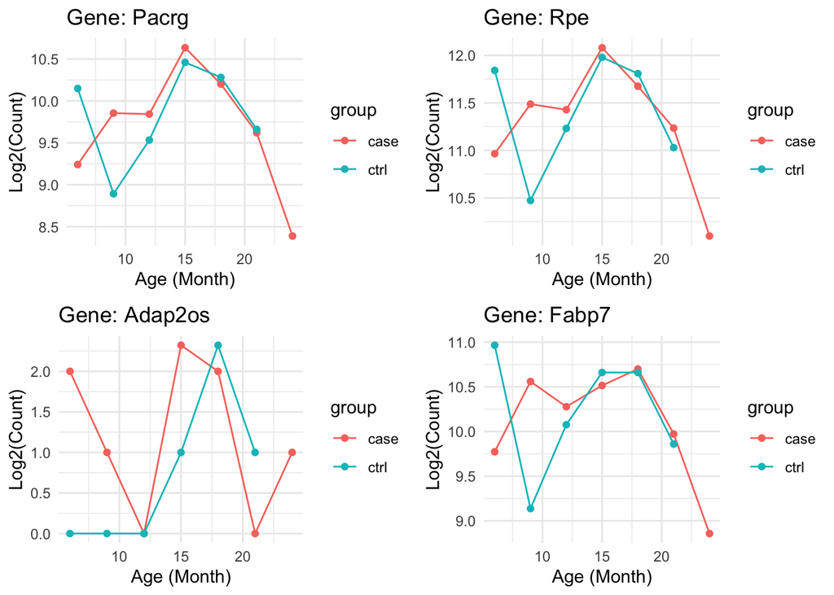

```r
# 提取感兴趣的基因
genes_of_interest <- c("Pacrg", "Rpe", "Adap2os", "Fabp7")
counts_subset <- counts[genes_of_interest, ]

# 转置 counts 数据框，使得基因为行，样本为列
counts_long <- as.data.frame(t(counts_subset))
counts_long$Sample_ID <- rownames(counts_long)

# 将 counts_long 和 sample_info_age_sex 合并
data_combined <- merge(counts_long, sample_info_age_sex, by.x = "Sample_ID", by.y = "row.names")

# 将数据从宽格式转换为长格式
data_long <- data_combined %>%
  pivot_longer(cols = starts_with("Pacrg") | starts_with("Rpe") | starts_with("Adap2os") | starts_with("Fabp7"),
               names_to = "gene",
               values_to = "count")


# 汇总数据
data_summarized <- data_long %>%
  group_by(age, group, gene) %>%
  summarise(total_count = sum(count, na.rm = TRUE), .groups = 'drop') %>%
  mutate(log2_count = log2(total_count + 1)) # 添加1以避免log2(0)

# 创建一个基因列表
genes <- c("Pacrg", "Rpe", "Adap2os", "Fabp7")

# 绘图函数
plot_gene <- function(gene_name, data) {
  ggplot(data %>% filter(gene == gene_name), aes(x = age, y = log2_count, color = group, group = group)) +
    geom_line() +
    geom_point() +
    labs(title = paste("Gene:", gene_name),
         x = "Age (Month)",
         y = "Log2(Count)") +
    theme_minimal()
}

# 绘制每个基因的图
plots <- lapply(genes, function(gene) {
  plot_gene(gene, data_summarized)
})

# 保存或展示图形
library(gridExtra)
do.call(grid.arrange, c(plots, ncol = 2))
```

```r
for (i in 1:length(plots)) {
  ggsave(filename = paste0(genes[i], "_plot.png"), plot = plots[[i]], width = 8, height = 6)
}
```